# Intermediate R

Albert Lee, Stephen Park  
August 3-4, 2018

### Agenda

1. Rmarkdown introduction
2. Problem Statement
3. Exploratory Analysis
4. Machine Learning with Caret
5. K-means Clustering in R

## R Markdown Notebook

### R-markdown Notebook

- R markdown notebook is a literate programming environment for R.
- It's nice because you can
  - keep all your outputs in one place
  - make your analysis reproducible
  - compile into other formats such as `html` or `pdf`
- We will do all the exercises in R markdown notebook

> Open ./exercises/intermediate/exercise.Rmd

## Iris Dataset

### Motivation

- `iris` is a famous dataset put together by the father of statistics, RA Fisher.
- We will use this dataset to practice data analysis
- Go to Exercise 1 P-001

source: Fisher,R.A. “The use of multiple measurements in taxonomic problems” (see [here](http://archive.ics.uci.edu/ml/datasets/Iris) for more info)

## Visualization

### Visualization with ggplot2

- Good exploratory analysis lends itself to visualization
- `ggplot2` is THE package for the job
- with `ggplot`, you can make complex plots with just a few lines of code
- based on the theory **g**rammar of **g**raphics, hence the short name `gg`plot.

### Visualization with ggplot2

Every ggplot has three parts

1. **data** (usually in the form of `data.frame`)
2. **aesthetic mapping** between variables in the data and the visual properties
   - examples include `x`, `y`, `color`, `share`, `group`, `size`, etc.
3. **layer** rendered by one of geom_* functions

### ggplot2 - (1) The Basics

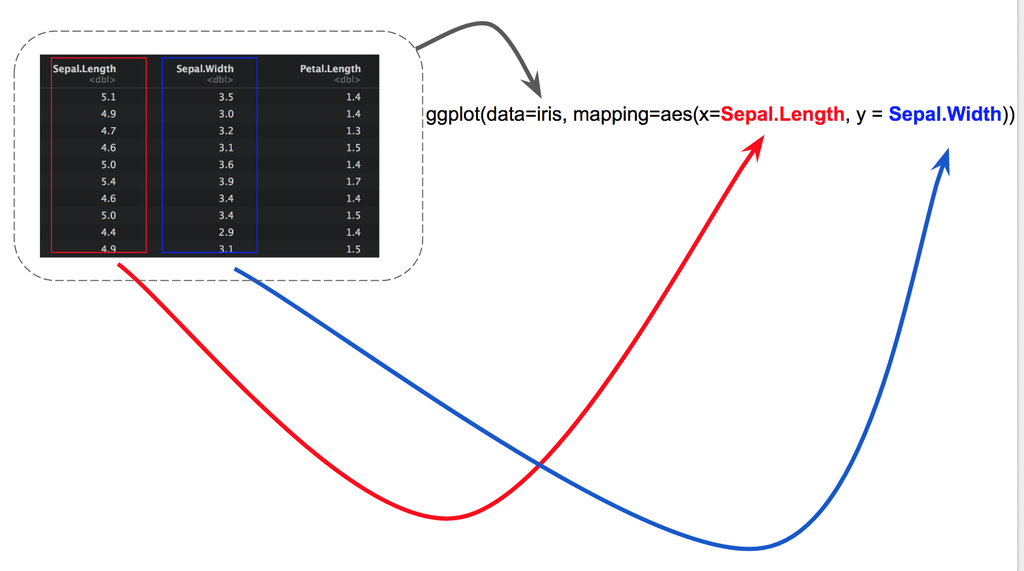

### ggplot2 - (1) The Basics

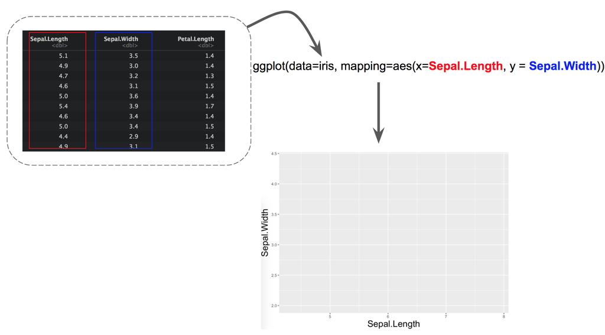

### ggplot2 - (1) The Basics

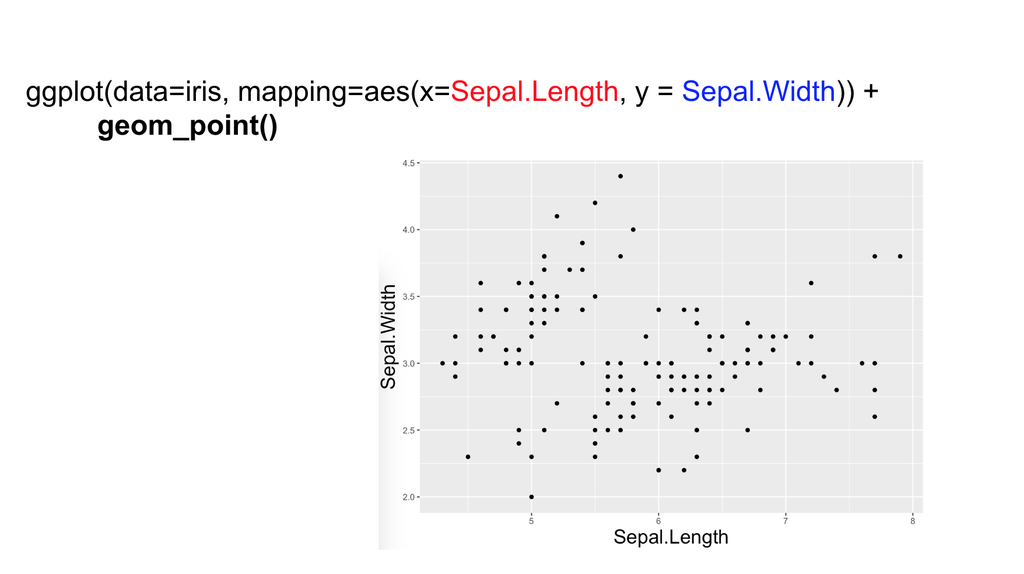

### ggplot2 - (1) The Basics

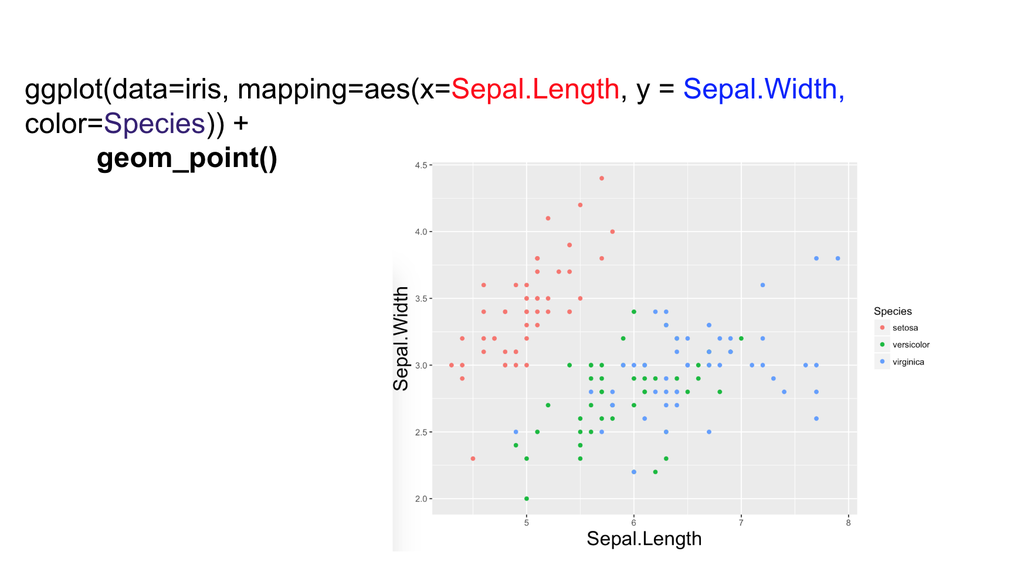

### Examples of Geoms

- **geom_point()** produces a scatterplot.
- **geom_smooth()** fits a smoother to the data and displays the smooth and its standard error.
- **geom boxplot()** produces a box-and-whisker plot to summarise the distribution of a set of points.
- **geom histogram()** and geom freqpoly() show the distribution of continuous variables. • **geom_col()** shows the distribution of categorical variables. • **geom_line()** draw lines between the data points.

### ggplot2 - (2) Layers

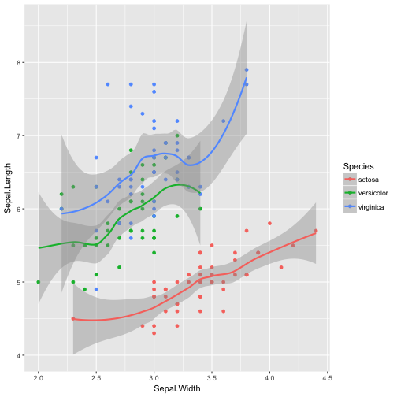

```r
ggplot(iris, aes(x=Sepal.Width, y=Sepal.Length, color=Species)) +
  geom_point() +
  geom_smooth() # Adding scatterplot geom (layer1) and smoothing geom (layer2).
```

### ggplot2 - (2) Layers

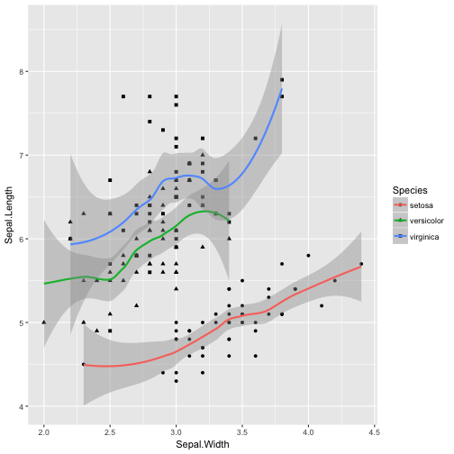

```r
ggplot(iris) +
  geom_point(aes(x=Sepal.Width, y=Sepal.Length, shape=Species)) +
  geom_smooth(aes(x=Sepal.Width, y=Sepal.Length, color=Species)) # Same as above but specifying the aesthetics inside the geoms.
```

### ggplot2 - (3) Labels

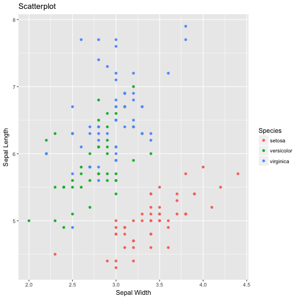

```r
gg <- ggplot(iris, aes(x=Sepal.Width, y=Sepal.Length, color=Species)) +
  geom_point() +
  labs(title="Scatterplot", x="Sepal Width", y="Sepal Length")  # add axis lables and plot title.
gg
```

### ggplot2 - (4) The Facets

There is a technique called `faceting` to display additional categorical variables:

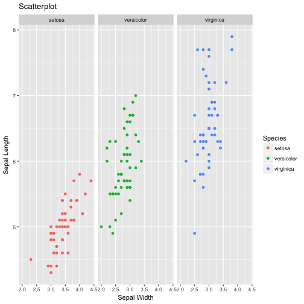

```r
gg +
  facet_wrap( ~ Species, ncol=3)  # columns defined by 'Species'
```

Note that the name of variable is preceded by `~`.

### Numerous Possibilites in ggplot2...

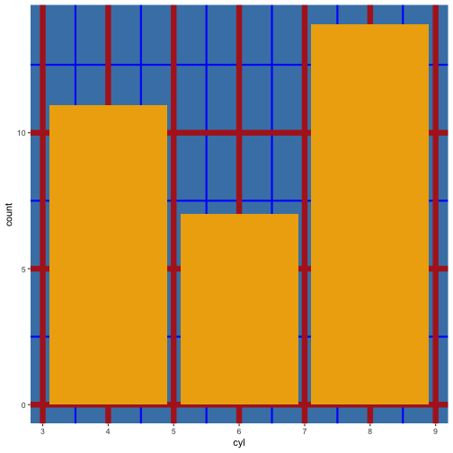

```r
ggplot(mtcars, aes(x=cyl)) + geom_bar(fill='darkgoldenrod2') +
  theme(panel.background = element_rect(fill = 'steelblue')) +
  theme(panel.grid.major = element_line(colour = "firebrick", size=3)) +
  theme(panel.grid.minor = element_line(colour = "blue", size=1))
```

### ggplot2 Documentation

[Link](https://github.com/rstudio/cheatsheets/raw/master/data-visualization-2.1.pdf)

[figure not shown]

### Visualization Exercise

- Go to the section `Exercise 2(P-002)` on the notebook and let's do the problems together

## Machine Learning

### Machine Learning

What is ML?

> INPUT -> FUNCTION -> OUTPUT

Basically, given `INPUT` and `OUTPUT`, What is FUNCTION?

### Two Types of ML: Supervised vs. Unsupervised Learning

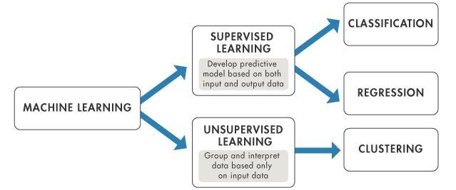

### Classification Problem

**Question: can we guess the type of species based on 4 features?**

```
# A tibble: 9 x 5
  Sepal.Length Sepal.Width Petal.Length Petal.Width Species
         <dbl>       <dbl>        <dbl>       <dbl> <chr>
1         5.20        3.40         1.40       0.200 ???
2         5.00        3.40         1.60       0.400 ???
3         5.40        3.90         1.70       0.400 ???
4         6.00        2.20         4.00       1.00  ???
5         5.80        2.70         4.10       1.00  ???
6         6.20        2.90         4.30       1.30  ???
7         6.10        2.60         5.60       1.40  ???
8         7.70        2.60         6.90       2.30  ???
9         6.30        2.90         5.60       1.80  ???
```

There are more than one ways to solve this problem, but we will use a particular way to do this….

### Machine Learning Workflow

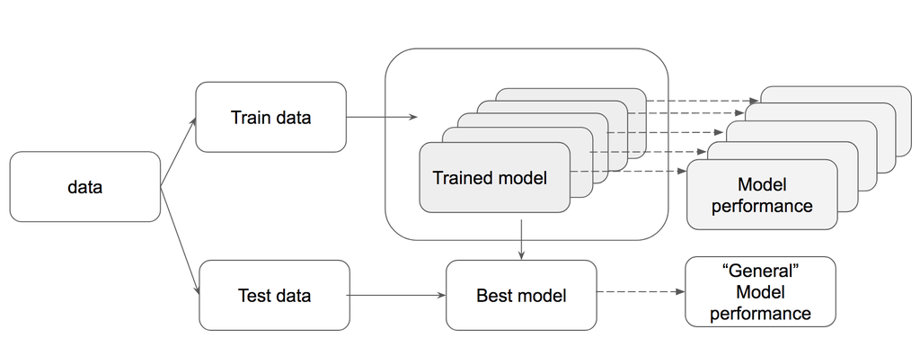

1. Why do we split a data into train/test datasets?

### What is caret?

- It stands for **C**lassification **A**nd **RE**gression **T**raining
- Machine learning framework in R
- Learn one workflow, leverage +100 models
- http://caret.r-forge.r-project.org/

```r
# type `help(package = "caret")` for more info
```

### Caret consists of 4 steps

1. Partition data into train / test data
2. Model Selection and Parameter tuning
3. Prediction
4. Performance check

### Training/Test Split

```r
set.seed(123)
idx_train <- caret::createDataPartition(
  y = iris$Species,
  p = .75,
  list = FALSE
)
```

1. What does `set.seed(123)` do?
2. Read the documentation of `caret::createDataPartition`
3. what does `p=0.75` mean?
4. can you `str(idx_train)` to see its structure?

### Training/Test Split

```r
str(idx_train)
```

```
 int [1:114, 1] 1 2 3 4 7 8 9 11 13 14 ...
 - attr(*, "dimnames")=List of 2
  ..$ : NULL
  ..$ : chr "Resample1"
```

```r
class(idx_train)
```

```
[1] "matrix"
```

### Training/Test Split

```r
head(idx_train)
```

```
     Resample1
[1,]         1
[2,]         2
[3,]         3
[4,]         4
[5,]         7
[6,]         8
```

### Training/Test Split Cont

```r
data_all <- iris
data_training <- data_all[idx_train, ]
data_test <- data_all[-idx_train, ]
```

1. what am I doing here?
2. what does `-idx_train` mean?
3. can you run `dim` commands on each of the dataset?

```r
dim(data_all)
dim(data_training)
dim(data_test)
```

### Model Building - Choosing a model

- There are many off-the-shelf classification models
  1. random forest
  2. K-nearest neighbor
  3. logistic regression
  4. and more

### Model Building - Choosing a model

- Each model has one or more tuning parameters!

| label | model | params |
| --- | --- | --- |
| Random Forest | rf | mtry |
| k-Nearest Neighbors | knn | k |
| glmnet | glmnet | alpha, lambda |
| eXtreme Gradient Boosting | xgbTree | nrounds, max_depth, eta, gamma, colsample_bytree, min_child_weight, subsample |

- We will use random forest for this session

### Model Building - Random Forest, quickstart

```r
# train model
model_rf <- caret::train(Species ~ . ,
                         data=data_training,
                         method='rf',
                         trControl=trainControl(method="none"),
                         tuneGrid=data.frame(mtry=2)
                         )
# predict
data_pred <- predict(model_rf, newdata=data_test)

# performance check
caret::confusionMatrix(data_pred, data_test$Species)
```

### Model Building - Random Forest, problem

- For `rf`, `mtry` is number of variables randomly sampled as candidates at each split
- previously, we just choose an arbitrary one, namely 2.
- But this approach is problematic because we might not have chosen the best `mtry`.

### Model Building - Cross Validation

- Cross-validation is a procedure in which we use different subsets of the data to get multiple measures of model quality.
- We use CV to tune hyperparameters such as `mtry`
- `caret`'s got a function for that!

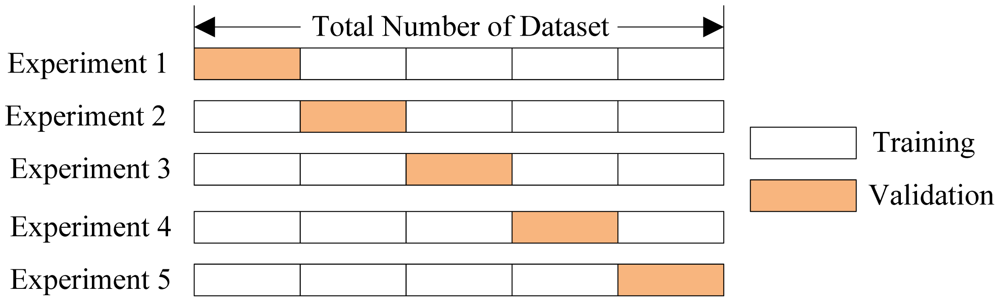

### Model Building - Cross Validation in caret

```r
ctrl <- caret::trainControl(
  method = "cv",
  number = 5,
)

model_rf2 <- caret::train(
  x = data_training[,1:4],
  y = data_training$Species,
  trControl = ctrl,
  tuneGrid=data.frame(mtry=c(1,2,3,4)),
  method = "rf",
)
```

### Model Building

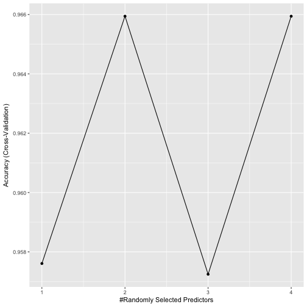

```r
ggplot(model_rf2)
```

### Prediction

```r
data_pred_class <- predict(model_rf2, newdata=data_test)
```

### Prediction

```r
confusionMatrix(data = data_pred_class, data_test$Species)
```

1. what is the sensitivity?
2. what is the accuracy?

### Variable Importance

```r
caret::varImp(model_rf2)
```

```
rf variable importance

             Overall
Petal.Length  100.00
Petal.Width    99.57
Sepal.Length   20.74
Sepal.Width     0.00
```

1. What variables are important?
2. Can you confirm this with a plot?

### Variable Importance

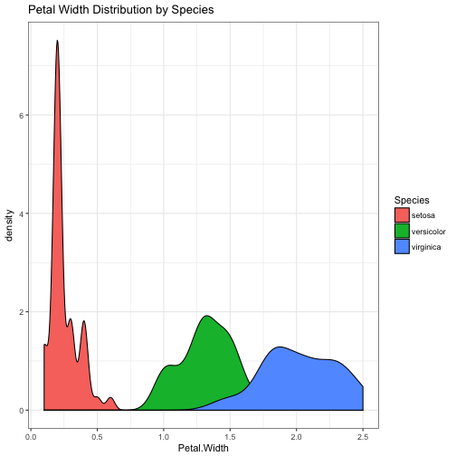

```r
ggplot(iris, aes(x=Petal.Width, fill=Species)) +
  geom_density() +
  theme_bw() +
  labs(title="Petal Width Distribution by Species")
```

### Excercise

Let's do the exercise together

### More sophisticated version

```r
model_v2 <- caret::train(
  x = data_training[,1:4],
  y = data_training$Species,
  trControl = ctrl,
  method = "rf",
  ## Center and scale the predictors for the training
  ## set and all future samples.
  preProc = c("center", "scale"),
  metric="logLoss"
)
```

### Tips

```r
info_caret_models  <- caret::getModelInfo()
head(names(info_caret_models))
```

```
[1] "ada"         "AdaBag"      "AdaBoost.M1" "adaboost"    "amdai"
[6] "ANFIS"
```

### You can do Regression with caret as well

```r
ctrl <- caret::trainControl(method="cv", number = 10)
model_linear <- caret::train(x = data_training[,1:3],
             y = data_training$Petal.Width,
             method = "lm",
             trControl = ctrl,
             metric="RMSE")
caret::RMSE(predict(model_linear, newdata=data_test), data_test$Petal.Width)
```

```
[1] 0.1748445
```

## Unsupervised Machine Learning: Clustering

### Unsupervised Machine Learning: Clustering

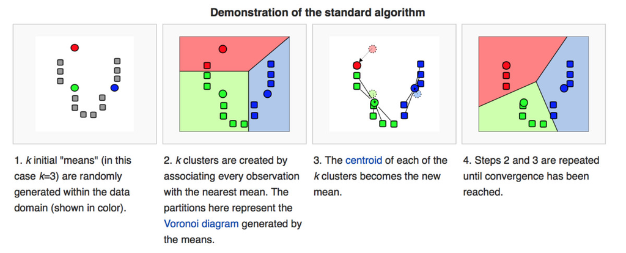

### K-means Clustering of the Iris Data

```r
set.seed(278613)
iris_without_class <- iris[, which(names(iris) != "Species")]
results <- kmeans(x = iris_without_class, centers = 3)
head(results, n=2)
```

```
$cluster
  [1] 2 2 2 2 2 2 2 2 2 2 2 2 2 2 2 2 2 2 2 2 2 2 2 2 2 2 2 2 2 2 2 2 2 2 2
 [36] 2 2 2 2 2 2 2 2 2 2 2 2 2 2 2 1 1 3 1 1 1 1 1 1 1 1 1 1 1 1 1 1 1 1 1
 [71] 1 1 1 1 1 1 1 3 1 1 1 1 1 1 1 1 1 1 1 1 1 1 1 1 1 1 1 1 1 1 3 1 3 3 3
[106] 3 1 3 3 3 3 3 3 1 1 3 3 3 3 1 3 1 3 1 3 3 1 1 3 3 3 3 3 1 3 3 3 3 1 3
[141] 3 3 1 3 3 3 1 3 3 1

$centers
  Sepal.Length Sepal.Width Petal.Length Petal.Width
1     5.901613    2.748387     4.393548    1.433871
2     5.006000    3.428000     1.462000    0.246000
3     6.850000    3.073684     5.742105    2.071053
```

### Base Scatterplots for the Petals

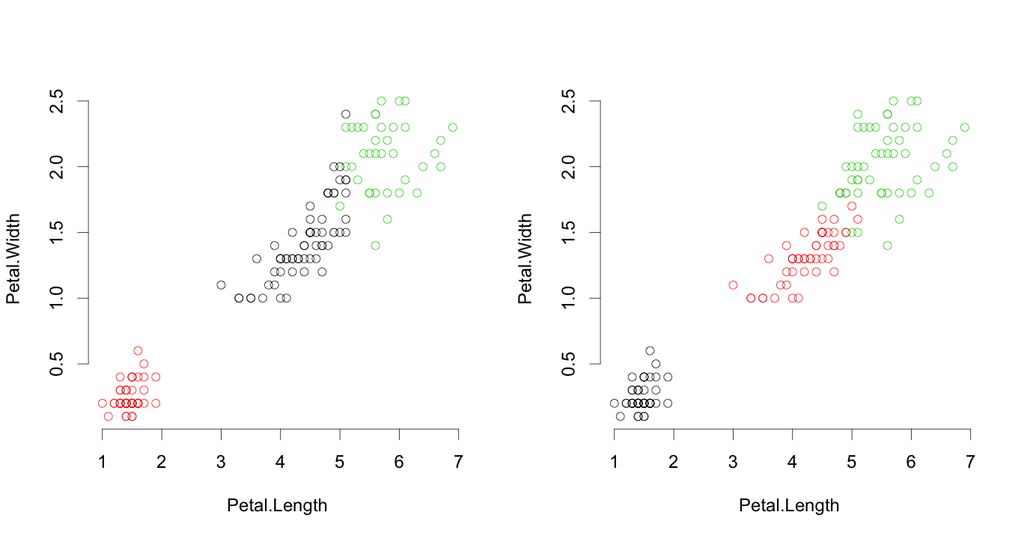

```r
par(mfrow=c(1,2), bty="n", cex=2)
plot(iris[c("Petal.Length", "Petal.Width")], col=results$cluster)
plot(iris[c("Petal.Length", "Petal.Width")], col=iris$Species)
```

### Base Scatterplots for the Sepals

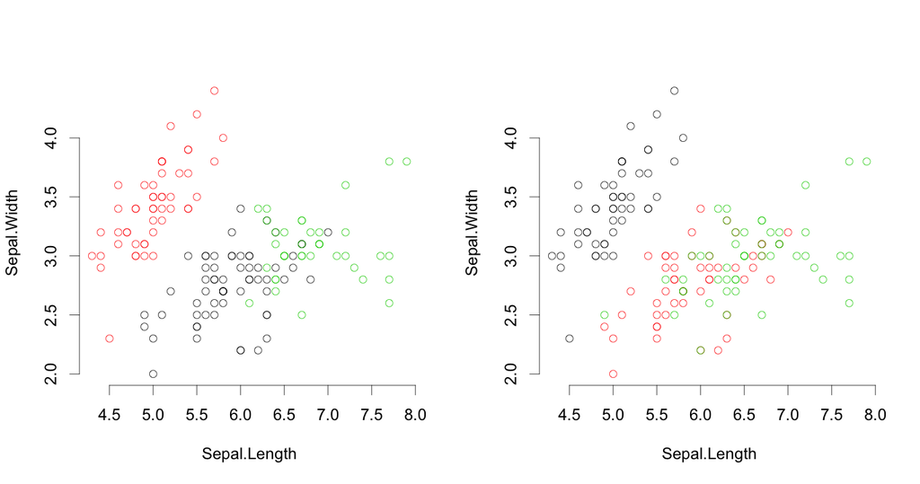

```r
par(mfrow=c(1,2), bty="n", cex=2)
plot(iris[c("Sepal.Length", "Sepal.Width")], col=results$cluster)
plot(iris[c("Sepal.Length", "Sepal.Width")], col=iris$Species)
```

### Analyzing the Clustering Results

```r
table(iris$Species, results$cluster)
```

```
              1  2  3
  setosa      0 50  0
  versicolor 48  0  2
  virginica  14  0 36
```

1. Which Iris plant is linearly separable from the other?
2. Does the results of the K-means clustering show “the data set contains 3 classes of 50 instances each, where each class refers to a type of iris plant”?

### Fit Assessment of K-means Clustering

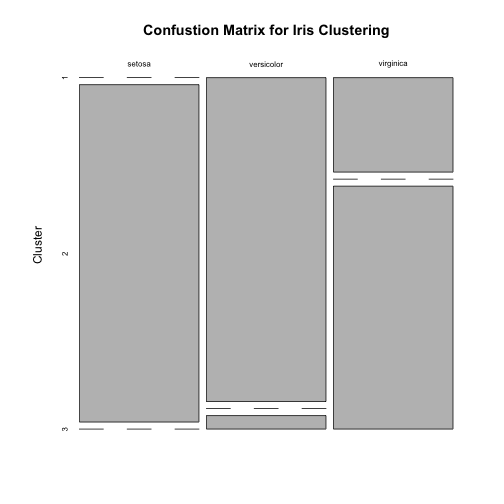

```r
plot(table(iris$Species, results$cluster), main="Confustion Matrix for Iris Clustering", "xlab=Cultivar", ylab="Cluster")
```

### Choosing the Right Number of Clusters: Hartigan's Rule

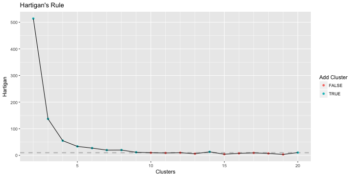

```r
irisBest <- FitKMeans(iris_without_class, max.clusters=20, nstart=25)
PlotHartigan(irisBest)
```

### Another Method: the Gap Statistic

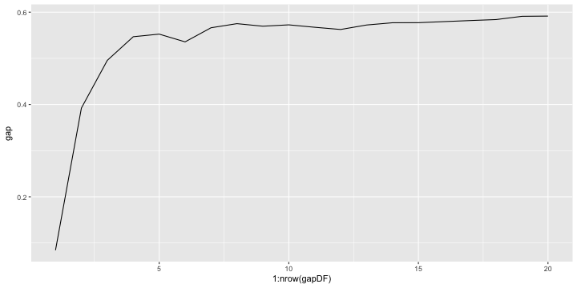

```r
theGap <- clusGap(iris_without_class, FUNcluster=pam, K.max=20)
gapDF <- as.data.frame(theGap$Tab)
ggplot(gapDF, aes(x=1:nrow(gapDF))) + geom_line(aes(y=gap))
```

### Futher studies

1. [Caret Documentation](https://topepo.github.io/caret/index.html)
2. [R for Data Science](http://r4ds.had.co.nz/)
3. ggplot2 - Elegant Graphics for Data Analysis by Hadley Wickham